# Glider sampling simulation figures

Doug Kinzey, AERD

08/17/2021

# Load the database of acoustic backscatter coefficients (s[a])

```r
load('NASC_leg1.RData')
```

# Figure 2: Sample paths of 3 yos to maximum depth of 150 m, and 1000 m

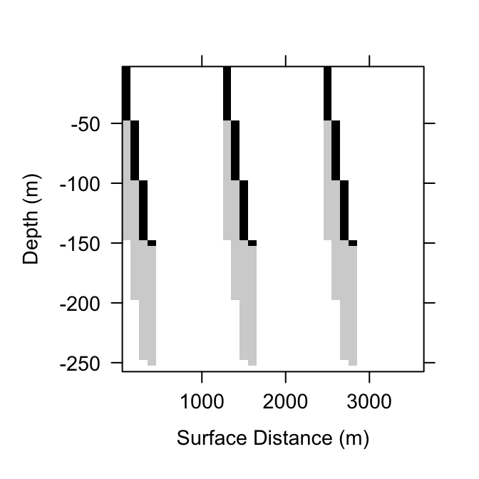

```r
source('Fig2.r')
Fig2()
```

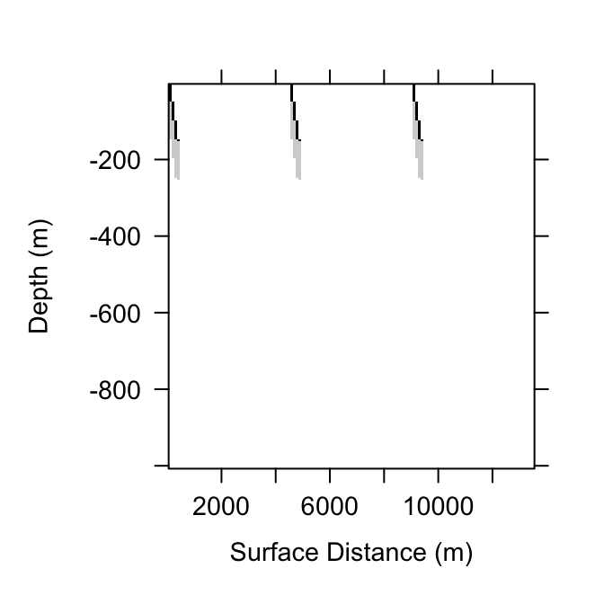

```r
Fig2(yo.depths.m=rep(1000,3),max.z.m=1005)
```

Figure 2. Schematic sample path of a glider completing 3 dives at with a maximum depth of (a) 150 m and (b) 1000 m. In each case the echosounder is shut off at 150 m, but the water column is ensonified to 250 m. Black cells indicate when the echosounder is recording and light gray represents the 100 m sampled below the glider. We computed a mean backscatter across the cells within each depth bin sampled during a dive and then summed vertically to produce glider samples of depth-integrated backscatter.

# Figure 3: Plot the summed s[a] at each 5m depth in the database

‘Fig3.r’ calculates a plot of the summed s[a] values at each depth, illustrating the overall relationship of krill density with depth.

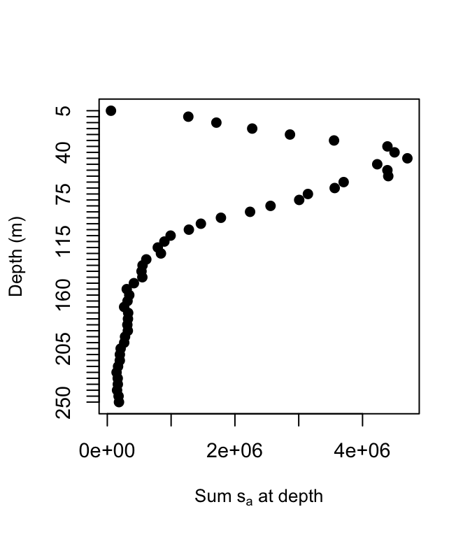

```r
source('Fig3.r')
```

# Figure 4: Plot the CV of s[a] and the proportion of zero density bins at each 5m depth in the database

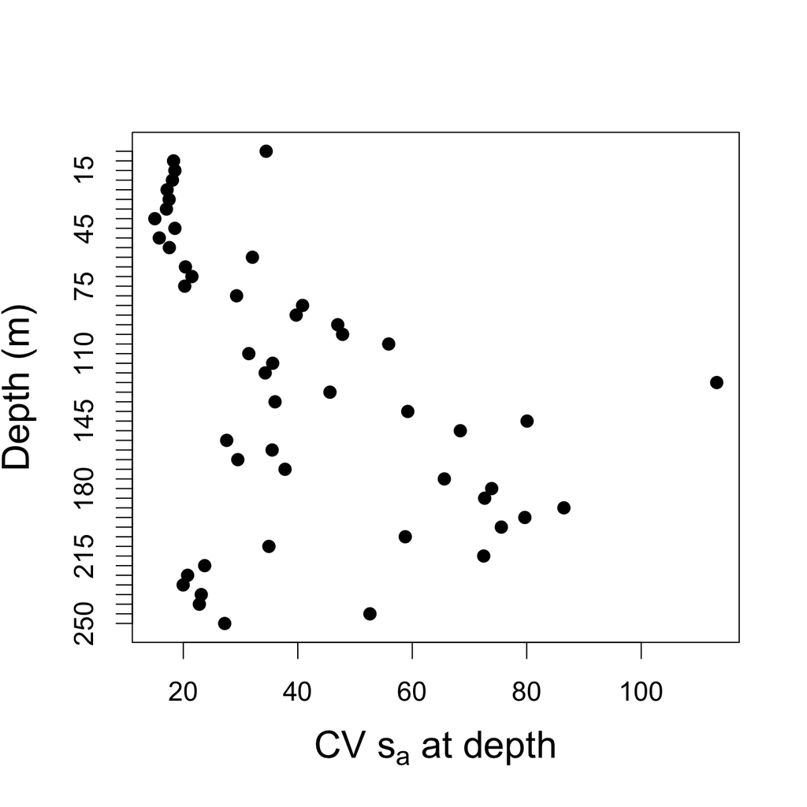

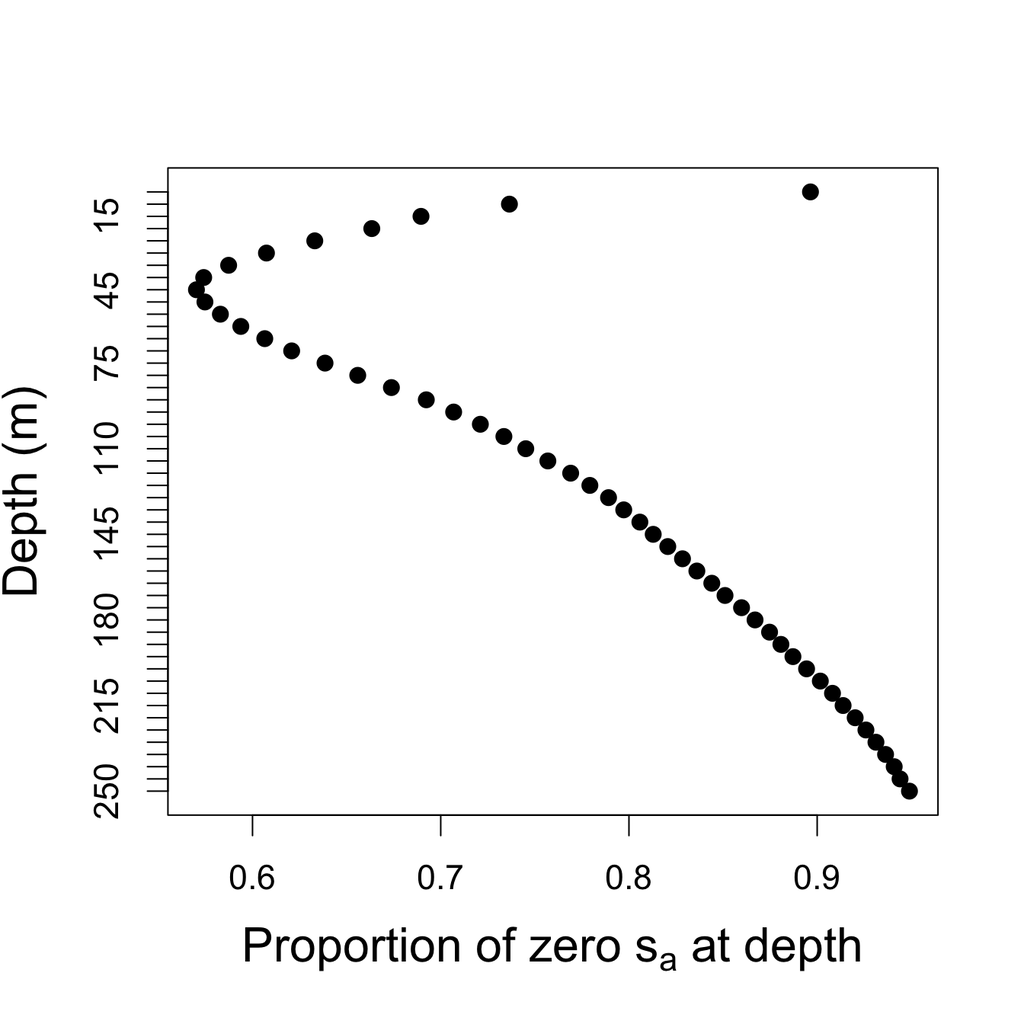

```r
source('Fig4.r')
```

Figure 4. CVs of acoustic backscatter (left) and proportions of bins with zero acoustic energy (right) at depth in the combined database sampled by the simulated gliders.